# Test 2

Loading the packages first

```r
library(pacman)
    p_load(tidyverse,dplyr, lavaan, psych, knitr, lme4, lmerTest, multilevel, nlme, lattice, sjPlot, ggplot2,cowplot, magrittr, broom, Metrics, pbkrtest, mlmRev, influence.ME, gridExtra, semPlot, plyr, kableExtra, ICC, irr,  lapply )
```

```
                  Question 1 – Structural Equation Modeling
```

loading data

```r
data <- readRDS("peru2.RDS")
```

Making variables for the path analysis for SEM. I would like to predict risky/antisocial behaviour using self-efficacy, early life SES (round 1 and 2), mental health and agency

```r
#   SES (Using the following variables: Housing quality, Access to services, Consumer durables)
    data$hq_r12<-data$hq_r12/3
    data$sv_r12<-data$sv_r12/3
    data$cd_r12<-data$cd_r12/3
    data$ses_scale<-data$hq_r12+data$sv_r12+data$cd_r12

#   self-efficacy
    data$self_eff1<-(data$self_eff1)/8
    data$self_eff2<-(data$self_eff2)/8
    data$self_eff3<-(data$self_eff3)/8
    data$self_eff4<-(data$self_eff4)/8
    data$self_eff5<-(data$self_eff5)/8
    data$self_eff6<-(data$self_eff6)/8
    data$self_eff7<-(data$self_eff7)/8
    data$self_eff8<-(data$self_eff8)/8
    data$self_efficacy_scale<-(data$self_eff1 + data$self_eff2 + data$self_eff3 + data$self_eff4 + data$self_eff5 + data$self_eff6 + data$self_eff7 + data$self_eff8)

#   agency
    data$agency1<-data$agency1/4
    data$agency2<-data$agency2/4
    data$agency3<-data$agency3/4
    data$agency4<-data$agency4/4
    data$agency_scale<-data$agency1+data$agency2+data$agency3+data$agency4

#   mental wellness
    data$sdq1<-data$sdq1/5
    data$sdq2<-data$sdq2/5
    data$sdq3<-data$sdq3/5
    data$sdq4<-data$sdq4/5
    data$sdq5<-data$sdq5/5
    data$mental_wellness_scale<-data$sdq1+data$sdq2+data$sdq3+data$sdq4+data$sdq5

#   anti-social, or risk-taking behaviour at Round 5

    data$FRNSMKR5<-data$FRNSMKR5/9 #Have friends who smoke
    data$FRNALCR5<-data$FRNALCR5/9 #Have friends who use alcohol
    data$YOUALCR5<-data$YOUALCR5/9 #Uses alcohol
    data$BEATEN<-data$BEATEN/9     #Beaten up by friends, strangers, teachers, parents
    data$ARRSTDR5<-data$ARRSTDR5/9 #Has been arrested
    data$FRNGNGR5<-data$FRNGNGR5/9 #Has friends in gang
    data$MEMGNGR5<-data$MEMGNGR5/9 #Is a member of a gang
    data$CRYWPNR5<-data$CRYWPNR5/9 #Has carried a weapon
    data$NUMPRTR5<-data$NUMPRTR5/9 #Number of sex partners had
    data$risky_behaviour_scale<-(data$FRNSMKR5 + data$FRNALCR5 + data$YOUALCR5 + data$BEATEN + data$ARRSTDR5 + data$FRNGNGR5 + data$MEMGNGR5 + data$CRYWPNR5 + data$NUMPRTR5)
```

Defining path model

```r
pathm1 <- '
      risky_behaviour_scale ~ self_efficacy_scale
      mental_wellness_scale ~ self_efficacy_scale
'
prejpathfit1 <- sem(pathm1, data = data)
summary(prejpathfit1, fit.measures = T)
```

```
lavaan 0.6-3 ended normally after 14 iterations

  Optimization method                           NLMINB
  Number of free parameters                          5

                                                  Used       Total
  Number of observations                          1559        1860

  Estimator                                         ML
  Model Fit Test Statistic                       0.000
  Degrees of freedom                                 0
  Minimum Function Value               0.0000000000000

Model test baseline model:

  Minimum Function Test Statistic              109.597
  Degrees of freedom                                 3
  P-value                                        0.000

User model versus baseline model:

  Comparative Fit Index (CFI)                    1.000
  Tucker-Lewis Index (TLI)                       1.000

Loglikelihood and Information Criteria:

  Loglikelihood user model (H0)              -1559.863
  Loglikelihood unrestricted model (H1)      -1559.863

  Number of free parameters                          5
  Akaike (AIC)                                3129.727
  Bayesian (BIC)                              3156.486
  Sample-size adjusted Bayesian (BIC)         3140.602

Root Mean Square Error of Approximation:

  RMSEA                                          0.000
  90 Percent Confidence Interval          0.000  0.000
  P-value RMSEA <= 0.05                             NA

```

[output cut: 11 more lines]

```
                          Estimate  Std.Err  z-value  P(>|z|)
  risky_behaviour_scale ~
    self_ffccy_scl          -0.044    0.027   -1.642    0.101
  mental_wellness_scale ~
    self_ffccy_scl           0.172    0.042    4.107    0.000

Covariances:
                           Estimate  Std.Err  z-value  P(>|z|)
 .risky_behaviour_scale ~~
   .mntl_wllnss_sc           -0.039    0.004   -9.106    0.000

Variances:
                   Estimate  Std.Err  z-value  P(>|z|)
   .risky_bhvr_scl    0.106    0.004   27.920    0.000
   .mntl_wllnss_sc    0.253    0.009   27.920    0.000
```

CFI and TLI are > .09 which shows that the model has a good fit, The model is shows a good fit, not too sure about the RMSEA, p-value =Na, might need to compare to another model

Now drawing model using package semPlot

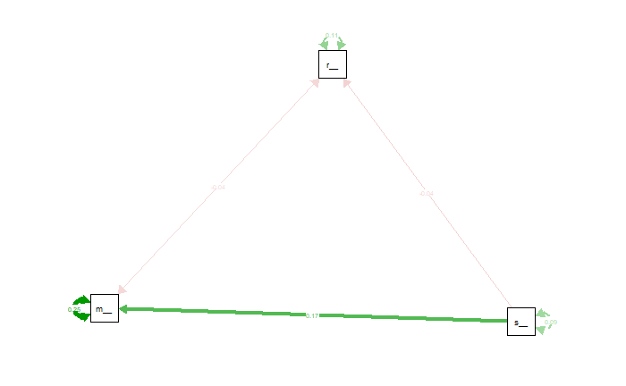

```r
semPlot::semPaths(prejpathfit1, what = "est", layout = "spring")
```

Defining path model 2

```r
pathm2 <- '
      risky_behaviour_scale ~ self_efficacy_scale + mental_wellness_scale
      mental_wellness_scale ~ self_efficacy_scale + agency_scale
      self_efficacy_scale ~  agency_scale
'
prejpathfit2 <- sem(pathm2, data = data)
summary(prejpathfit2, fit.measures = T)
```

```
lavaan 0.6-3 ended normally after 20 iterations

  Optimization method                           NLMINB
  Number of free parameters                          8

                                                  Used       Total
  Number of observations                          1523        1860

  Estimator                                         ML
  Model Fit Test Statistic                       2.076
  Degrees of freedom                                 1
  P-value (Chi-square)                           0.150

Model test baseline model:

  Minimum Function Test Statistic              445.819
  Degrees of freedom                                 6
  P-value                                        0.000

User model versus baseline model:

  Comparative Fit Index (CFI)                    0.998
  Tucker-Lewis Index (TLI)                       0.985

Loglikelihood and Information Criteria:

  Loglikelihood user model (H0)              -1689.030
  Loglikelihood unrestricted model (H1)      -1687.992

  Number of free parameters                          8
  Akaike (AIC)                                3394.060
  Bayesian (BIC)                              3436.687
  Sample-size adjusted Bayesian (BIC)         3411.273

Root Mean Square Error of Approximation:

  RMSEA                                          0.027
  90 Percent Confidence Interval          0.000  0.079
  P-value RMSEA <= 0.05                          0.695

```

[output cut: 11 more lines]

```
                          Estimate  Std.Err  z-value  P(>|z|)
  risky_behaviour_scale ~
    self_ffccy_scl          -0.010    0.026   -0.370    0.712
    mntl_wllnss_sc          -0.149    0.016   -9.312    0.000
  mental_wellness_scale ~
    self_ffccy_scl           0.259    0.047    5.552    0.000
    agency_scale            -0.168    0.034   -4.913    0.000
  self_efficacy_scale ~
    agency_scale             0.320    0.017   18.866    0.000

Variances:
                   Estimate  Std.Err  z-value  P(>|z|)
   .risky_bhvr_scl    0.098    0.004   27.595    0.000
   .mntl_wllnss_sc    0.249    0.009   27.595    0.000
   .self_ffccy_scl    0.075    0.003   27.595    0.000
```

```r
anova(prejpathfit2, prejpathfit1) #comparing this model to our first model
```

```
Chi Square Difference Test

             Df    AIC    BIC  Chisq Chisq diff Df diff Pr(>Chisq)
prejpathfit1  0 3129.7 3156.5 0.0000
prejpathfit2  1 3394.1 3436.7 2.0764     2.0764       1     0.1496
```

Now plotting this model

[figure not shown]

```r
semPlot::semPaths(prejpathfit2, what = "est", layout = "spring")
```

Let’s take a closer look at the residuals as our new model as the AIC is higher than the first model’s one and the RMSEA p-value is not significant

```r
      resid(prejpathfit2, type = "normalized")
```

```
$`type`
[1] "normalized"

$cov
                      rsky__ mntl__ slf_f_ agncy_
risky_behaviour_scale  0.000
mental_wellness_scale  0.000  0.000
self_efficacy_scale    0.000  0.000  0.000
agency_scale          -1.251  0.000  0.000  0.000
```

```r
      modificationindices(prejpathfit2)
```

|  | lhs | op | rhs | mi | epc | sepc.lv | sepc.all | sepc.nox |
| --- | --- | --- | --- | --- | --- | --- | --- | --- |
| 10 | risky_behaviour_scale | ~~ | mental_wellness_scale | 2.075 | -0.046 | -0.046 | -0.296 | -0.296 |
| 11 | risky_behaviour_scale | ~~ | self_efficacy_scale | 2.075 | 0.007 | 0.007 | 0.085 | 0.085 |
| 13 | risky_behaviour_scale | ~ | agency_scale | 2.075 | -0.031 | -0.031 | -0.040 | -0.097 |
| 14 | mental_wellness_scale | ~ | risky_behaviour_scale | 2.075 | -0.470 | -0.470 | -0.300 | -0.300 |
| 15 | self_efficacy_scale | ~ | risky_behaviour_scale | 2.075 | 0.075 | 0.075 | 0.079 | 0.079 |
| 17 | agency_scale | ~ | risky_behaviour_scale | 2.075 | -0.055 | -0.055 | -0.043 | -0.043 |

we can see correlation between the risky behaviour scale and the mental wellness and self-efficacy scales now lets respecify the model to allow correlations between the error terms in each scale

```r
  prejpathmodel2 <- '
                # MEASUREMENT MODEL
                  agency_scale =~ agency1 + agency2 + agency3 + agency4
                  self_efficacy_scale =~ self_eff1 + self_eff2 + self_eff3 + self_eff4 + self_eff5 + self_eff6                   + self_eff7 + self_eff8
                  mental_wellness_scale =~ sdq1 + sdq2 + sdq3 + sdq4 + sdq5
                  risky_behaviour_scale =~ FRNSMKR5 + FRNALCR5 + YOUALCR5 + BEATEN + ARRSTDR5 + FRNGNGR5 +                      MEMGNGR5 + CRYWPNR5 + NUMPRTR5

                # STRUCTURAL MODEL
                  risky_behaviour_scale ~ self_efficacy_scale + mental_wellness_scale
                  mental_wellness_scale ~ self_efficacy_scale + agency_scale
                  self_efficacy_scale ~  agency_scale

                # CORRELATED ERRORS
                  risky_behaviour_scale ~~  mental_wellness_scale
                  risky_behaviour_scale ~~  self_efficacy_scale

               '
#Fitting and summarising model
 prejpathfit3 <- sem(prejpathmodel2, data = data)
      summary(prejpathfit3, fit.measures = T)
```

```
lavaan 0.6-3 ended normally after 328 iterations

  Optimization method                           NLMINB
  Number of free parameters                         59

                                                  Used       Total
  Number of observations                          1523        1860

  Estimator                                         ML
  Model Fit Test Statistic                    1114.457
  Degrees of freedom                               292
  P-value (Chi-square)                           0.000

Model test baseline model:

  Minimum Function Test Statistic             6745.620
  Degrees of freedom                               325
  P-value                                        0.000

User model versus baseline model:

  Comparative Fit Index (CFI)                    0.872
  Tucker-Lewis Index (TLI)                       0.857

Loglikelihood and Information Criteria:

  Loglikelihood user model (H0)              46244.875
  Loglikelihood unrestricted model (H1)      46802.104

  Number of free parameters                         59
  Akaike (AIC)                              -92371.750
  Bayesian (BIC)                            -92057.372
  Sample-size adjusted Bayesian (BIC)       -92244.800

Root Mean Square Error of Approximation:

  RMSEA                                          0.043
  90 Percent Confidence Interval          0.040  0.046
  P-value RMSEA <= 0.05                          1.000

```

[output cut: 78 more lines]

```
   .sdq4              0.016       NA
   .sdq5              0.013       NA
   .FRNSMKR5          0.004       NA
   .FRNALCR5          0.004       NA
   .YOUALCR5          0.008       NA
   .BEATEN            0.006       NA
   .ARRSTDR5          0.000       NA
   .FRNGNGR5          0.003       NA
   .MEMGNGR5          0.000       NA
   .CRYWPNR5          0.001       NA
   .NUMPRTR5          0.005       NA
    agency_scale      0.007       NA
   .self_ffccy_scl    0.000       NA
   .mntl_wllnss_sc    0.005       NA
   .risky_bhvr_scl    0.002       NA
```

Now plotting this model

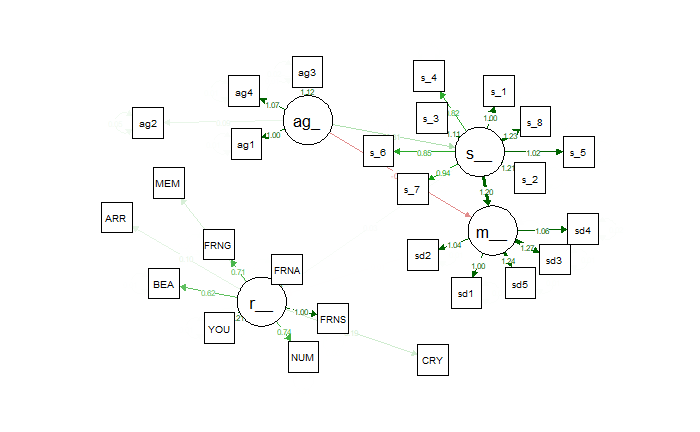

```r
semPlot::semPaths(prejpathfit3, what = "est", layout = "spring")
```

With the correlated errors we can see that the riscky behaviour scale is not linked to any of the other variables Let’s see waht happens if the correlated errors are excluded

```r
prejpathmodel3 <- '
                # MEASUREMENT MODEL
                  agency_scale =~ agency1 + agency2 + agency3 + agency4
                  self_efficacy_scale =~ self_eff1 + self_eff2 + self_eff3 + self_eff4 + self_eff5 + self_eff6                   + self_eff7 + self_eff8
                  mental_wellness_scale =~ sdq1 + sdq2 + sdq3 + sdq4 + sdq5
                  risky_behaviour_scale =~ FRNSMKR5 + FRNALCR5 + YOUALCR5 + BEATEN + ARRSTDR5 + FRNGNGR5 +                      MEMGNGR5 + CRYWPNR5 + NUMPRTR5

                # STRUCTURAL MODEL
                  risky_behaviour_scale ~ self_efficacy_scale + mental_wellness_scale
                  mental_wellness_scale ~ self_efficacy_scale + agency_scale
                  self_efficacy_scale ~  agency_scale


               '
#Fitting and summarising model
 prejpathfit4 <- sem(prejpathmodel3, data = data)
      summary(prejpathfit4, fit.measures = T)
```

```
lavaan 0.6-3 ended normally after 297 iterations

  Optimization method                           NLMINB
  Number of free parameters                         57

                                                  Used       Total
  Number of observations                          1523        1860

  Estimator                                         ML
  Model Fit Test Statistic                    1114.722
  Degrees of freedom                               294
  P-value (Chi-square)                           0.000

Model test baseline model:

  Minimum Function Test Statistic             6745.620
  Degrees of freedom                               325
  P-value                                        0.000

User model versus baseline model:

  Comparative Fit Index (CFI)                    0.872
  Tucker-Lewis Index (TLI)                       0.859

Loglikelihood and Information Criteria:

  Loglikelihood user model (H0)              46244.743
  Loglikelihood unrestricted model (H1)      46802.104

  Number of free parameters                         57
  Akaike (AIC)                              -92375.486
  Bayesian (BIC)                            -92071.765
  Sample-size adjusted Bayesian (BIC)       -92252.839

Root Mean Square Error of Approximation:

  RMSEA                                          0.043
  90 Percent Confidence Interval          0.040  0.045
  P-value RMSEA <= 0.05                          1.000

```

[output cut: 71 more lines]

```
   .sdq4              0.016    0.001   23.607    0.000
   .sdq5              0.013    0.001   20.967    0.000
   .FRNSMKR5          0.004    0.000   22.015    0.000
   .FRNALCR5          0.004    0.000   19.166    0.000
   .YOUALCR5          0.008    0.000   23.771    0.000
   .BEATEN            0.006    0.000   26.389    0.000
   .ARRSTDR5          0.000    0.000   26.520    0.000
   .FRNGNGR5          0.003    0.000   24.070    0.000
   .MEMGNGR5          0.000    0.000   26.384    0.000
   .CRYWPNR5          0.001    0.000   27.038    0.000
   .NUMPRTR5          0.005    0.000   25.646    0.000
    agency_scale      0.007    0.001    9.509    0.000
   .self_ffccy_scl    0.000    0.000    6.749    0.000
   .mntl_wllnss_sc    0.005    0.001   10.078    0.000
   .risky_bhvr_scl    0.002    0.000   10.796    0.000
```

The summary is still the same as that of the previous model, now let’s see the diagram

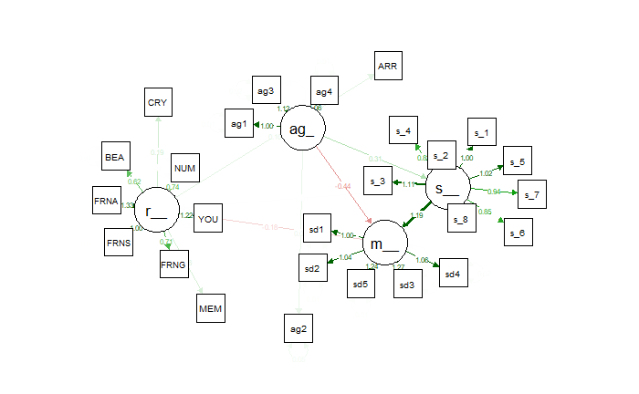

```r
semPlot::semPaths(prejpathfit4, what = "est", layout = "spring")
```

We can now see that the risky behaviour scale is now icluded in the relationship tree. The model shows that agency is a predictor of both self-efficacy and mental wellnenss, and mental illness is in turn a predictor of risky behaviour

```r
#COMPARE models 2 and 3
    anova(prejpathfit2, prejpathfit3)
```

[output not shown]

```
                            Question 2 Mixed-Effects Models
```

2.1 Loading datasets

```r
ethp  <- load("YL_June2017_Ethiopiadata_2017-09-08")
india <- load("YL_June2017_Indiadata_2017-11-22")
peru  <- load("YL_June2017_perudata_2017-11-12")
viet  <- load("YL_June2017_Vietnamdata_2017-11-01")
```

Now merging datasets

```r
mylist <- list( one=Ethiopia.dat, two=India.dat, three=peru.dat, four= Vietnam.dat )
joined <- join_all( mylist, type="full" )
```

2.1 Making new dataset with only the necessary variables